The Case of Former Countries

An Examination of 31 Countries that no longer have an ISO Country Code

Changed Country Name

Country Splitted

Country Merged

Became a Subdivision

Reason Unclear

Former Name

New Name

Date Withdrawn

French Afars and Issas

Djibouti

Dahomey

Benin

Gilbert and Ellice Islands

Kiribati

New Hebrides

Vanuatu

Southern Rhodesia

Zimbabwe

Upper Volta, Republic of

Burkina Faso

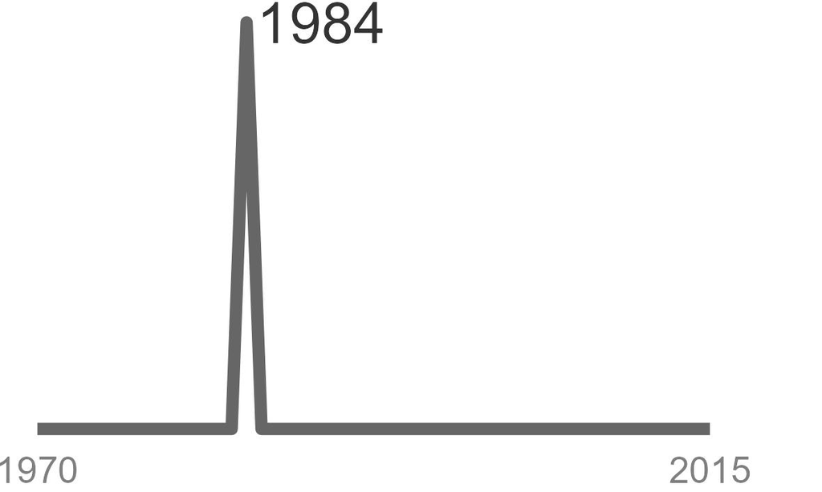

Burma, Socialist Republic of the Union of

Myanmar

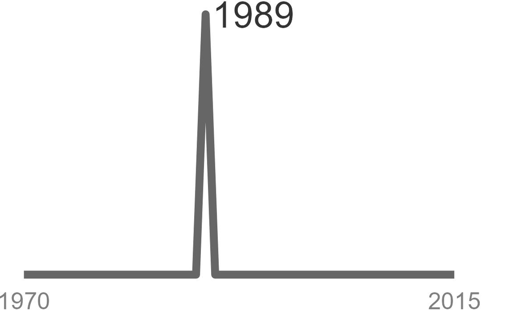

Byelorussian SSR Soviet Socialist Republic

Belarus

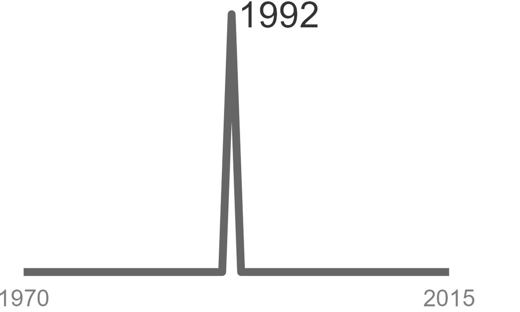

Zaire, Republic of

Congo, The Democratic Republic of the

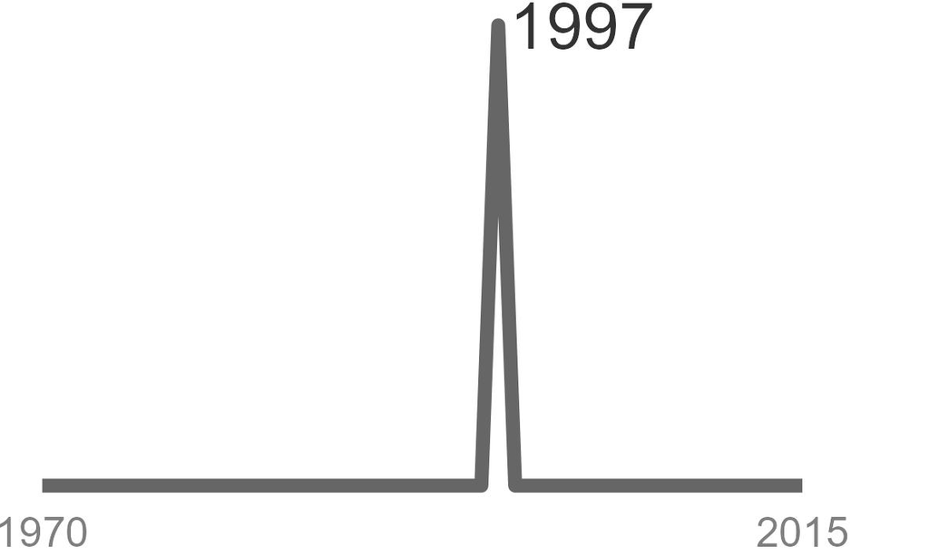

East Timor

Timor-Leste

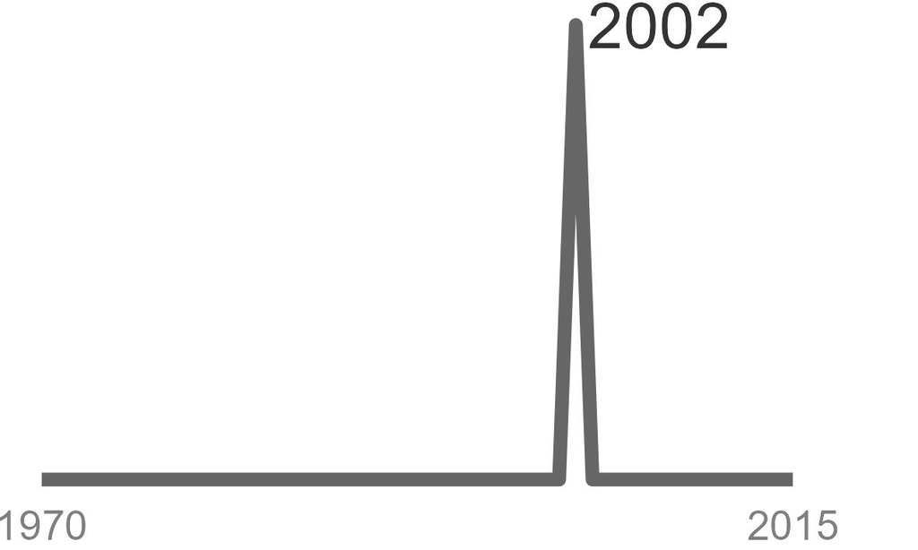

Former Name

Date Withdrawn

French Southern and Antarctic Territories

Pacific Islands (trust territory)

USSR, Union of Soviet Socialist Republics

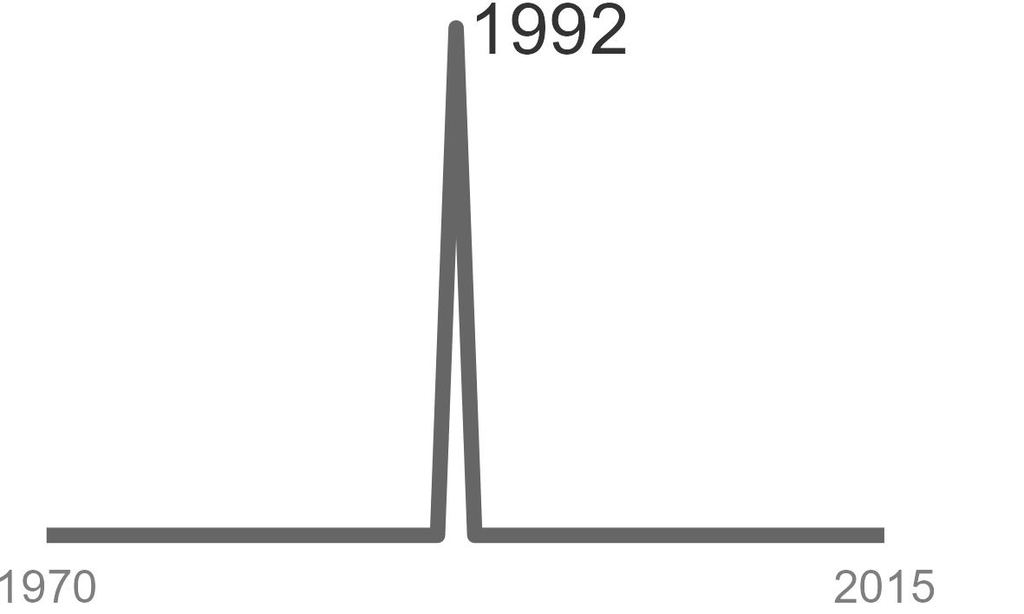

Neutral Zone

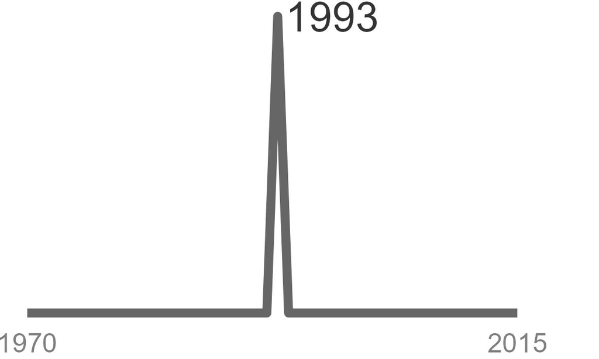

Czechoslovakia, Czechoslovak Socialist Republic

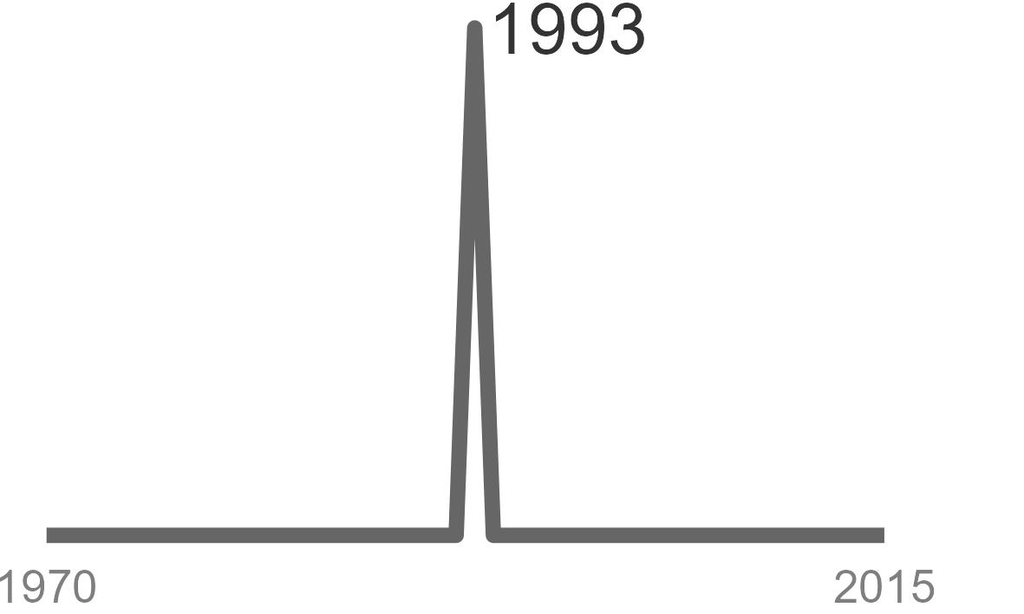

Yugoslavia, (Socialist) Federal Republic of

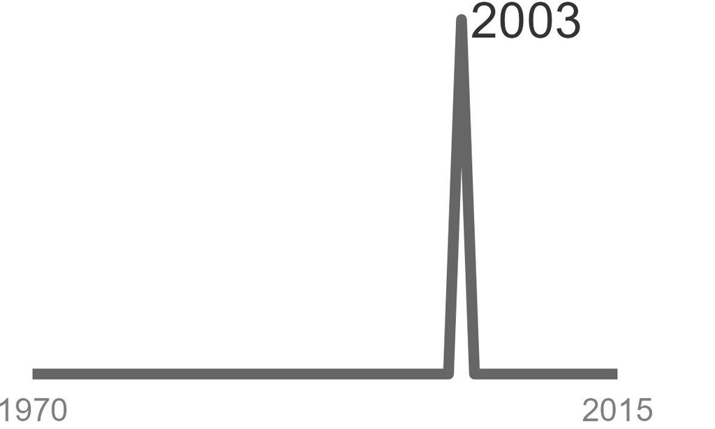

Serbia and Montenegro

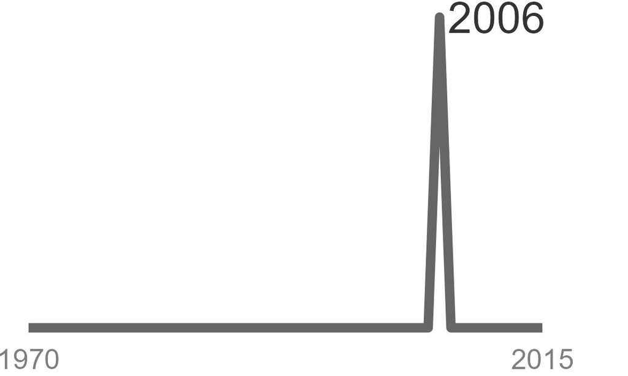

Netherlands Antilles

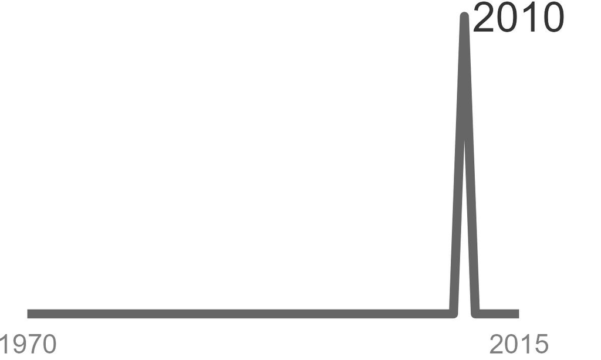

Former Name

Country Merged Into

Date Withdrawn

Viet-Nam, Democratic Republic of

Viet Nam

Panama Canal Zone

Panama

Canton and Enderbury Islands

Kiribati

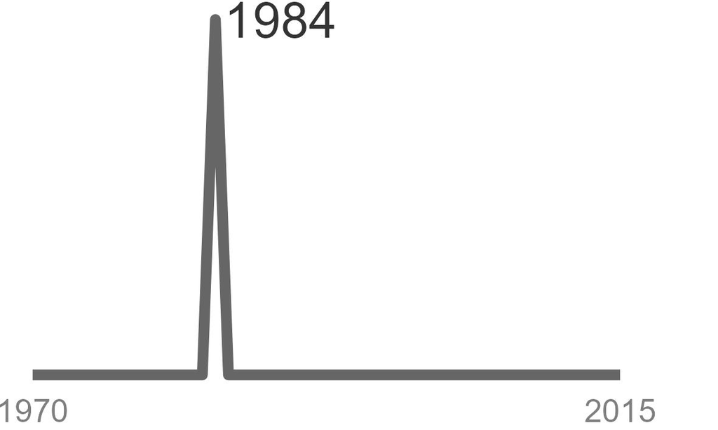

US Miscellaneous Pacific Islands

Marshall Islands

German Democratic Republic

Germany

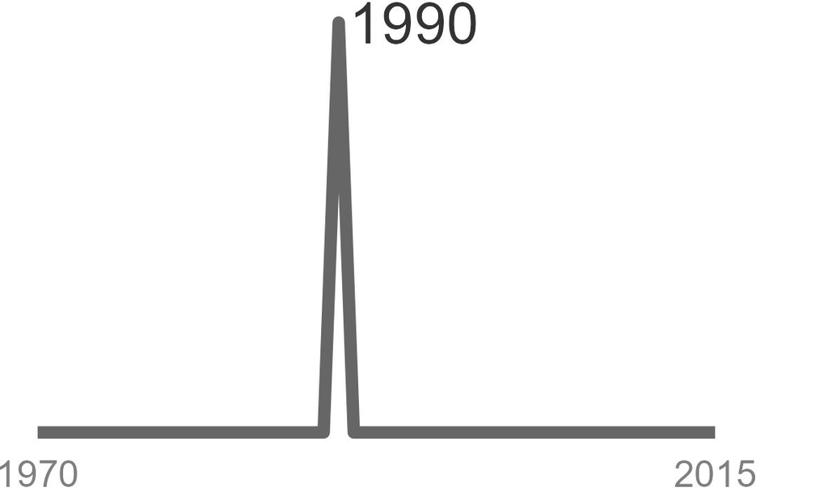

Yemen, Democratic, People's Democratic Republic of

Yemen

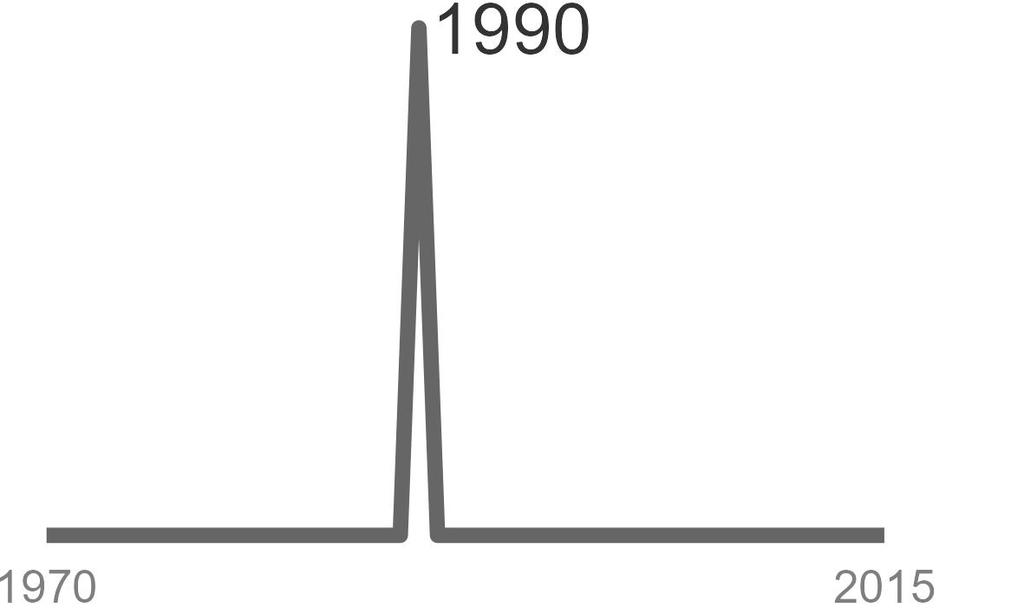

France, Metropolitan

France

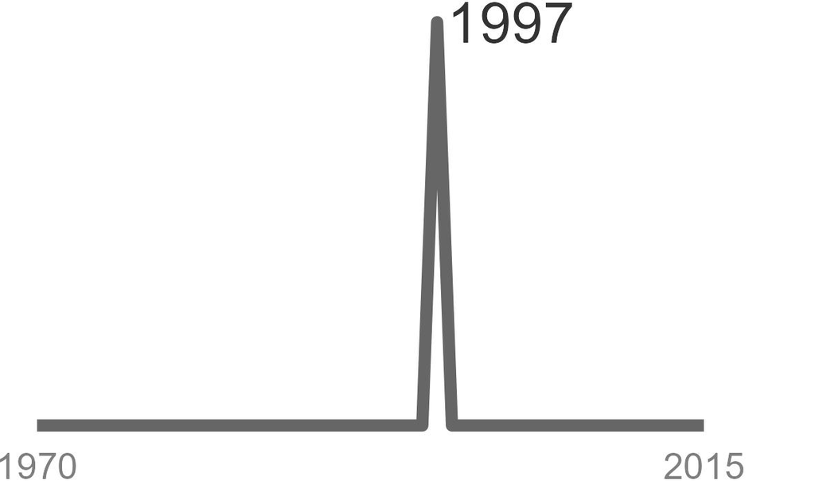

Name

Former Code

New Code

Date Withdrawn

Sikkim

SKM

IN-SK

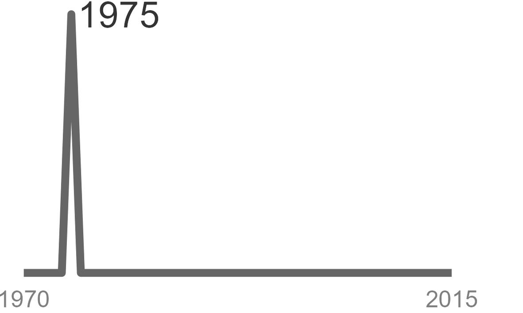

Midway Islands

MID

UM-71

Wake Island

WAK

UM-79

Former Name

Date Withdrawn

British Antarctic Territory

Dronning Maud Land

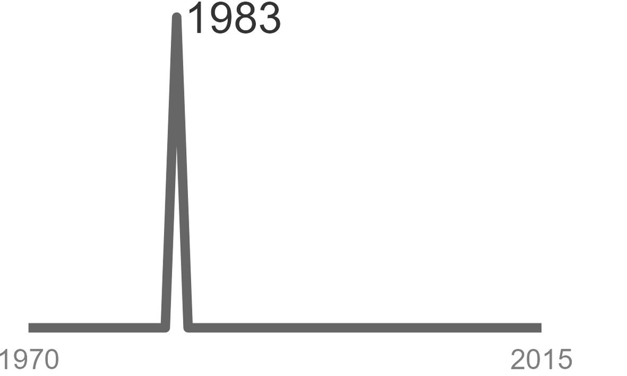

Johnston Island

Source: ISO Country Code, #TidyTuesday